# IODS course final project

Rigbe G. Weldatsadik (rigbe.weldatsadik@helsinki.fi)

10/12/2016

Abstract

Portugese students have a high failure rate compared to other European countries especially in the two subjects, Mathematics and the Portugese Language(Cortez and Silva, 2008). To understand the possible reasons behind poor performances, data containing different metrics including school and social life of students in two Portugese high schools was collected from school reports and surveys. I have utilized this dataset to complete the final project assignment of the open data science course. I used Linear regression and LDA to identify statistically significant explanatory variables for the final grades of the students in the two subjects and also to identify components that could predict the final grades. I chose to apply the methods individually to the two subjects to identify the common and also different variables that are related to the performances of students in these two subjects. In addition, as it is obvious that the final grade will be highly affected by to the previous two grades, I did the analyses without these grades to identify other explanatory variables that might affect the final grade. I fitted two lm models such that I used almost all of the variables in one of the models while I used the Variance Inflation Factor (VIF) test to select predictors in the other model. According to the anova.lm method the model with more variables does not appear to improve the fit of the model(p-value 0.22). According to the Linear Regression analysis with almost all the predictor variables used, the variables ‘reason for choosing the school’, ‘student’s age’, ‘parent’s cohabitation status’, ‘mother’s job’, ‘father’s job’, ‘home to school travel time’, and ‘number of past class failures’ had a statistically significant relationship to the final mathematics grades of students while only the variable ‘extra educational school support’ had a statistically significant relationship with the final Portugese language grades. The LDA’s prediction performance was very low as examined by the ROC curve for both the mathematics and Portugese final grades.

# 1. Research question and hypothesis

- What variables besides the previous grades affect the final grades of students ?
- Do these factors differ between the two subjects studied ?
- Can we predcit the final grades of students based on some of these factors ?
- Hypothesis : the previous grades will highly impact the final grade (but am curious to see what other variables can be related to the grades and I believe different predictors are related differently to each subject)

# 2. A link to data wrangling script: [finalProj_wrangling](https://github.com/Rigbe-ods/IODS-final/blob/master/final_project_dataWrangling.r)

# 3. Description of data and its variables

The data contains demographic, social and performance related information about students in two Portugese high schools. The variables in the dataset with their descriptions are shown below.

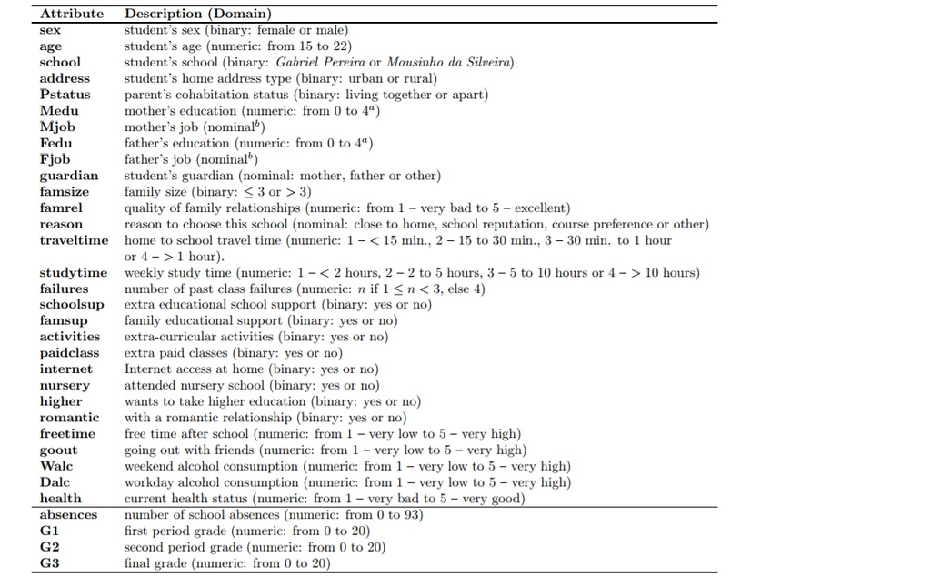

## 4. Explorations of the variables of interest

In multivariate regression, even though it is tempting to use all predictor variables to explain the response,we must make sure that the predictors we are using are not explaining the same variance in our response variable because then they will be redundant. To test multicolinearity we could check the scatter plot matrix of all variables (using R’s pairs() function for instance) or we could also use the Variance Inflation Factor (VIF) test ($VIF = \frac{1}{1 - R^2_1}$). Since the number of variables to be plotted would be very large with pairs, I will only plot the scatter matrix of a few of those variables(Medu vs Fedu and Dalc vs Walc and also the G1 and G2s) that were discarded for having high VIF(>3) (from the data wrangling part) to show those values were indeed correlated.

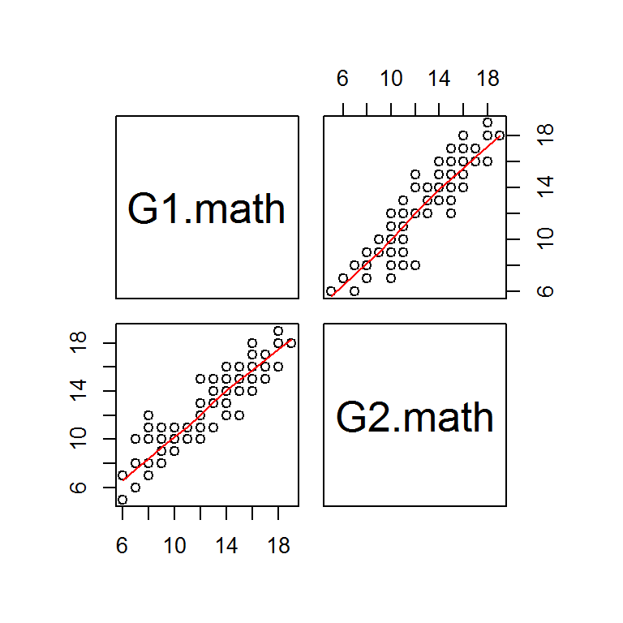

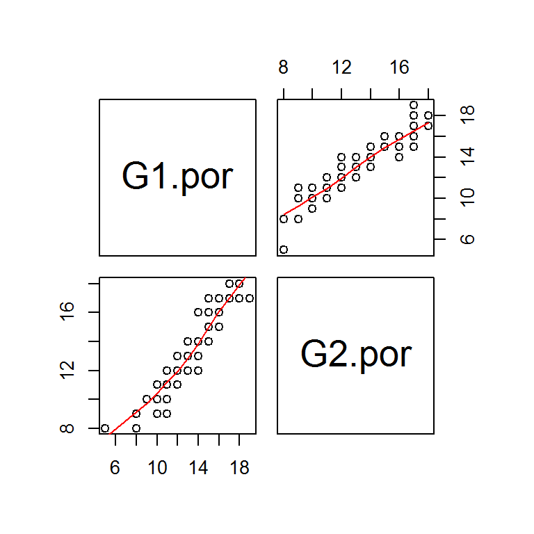

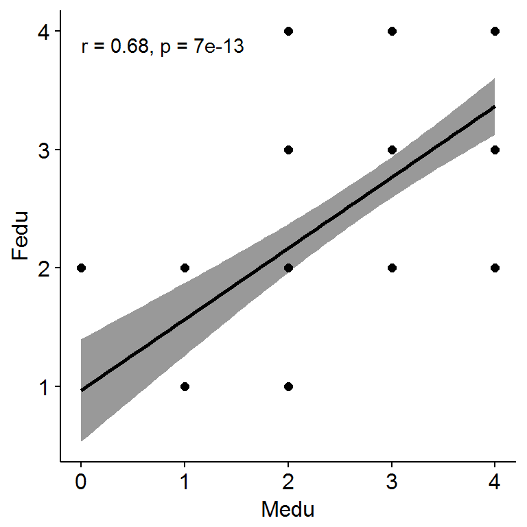

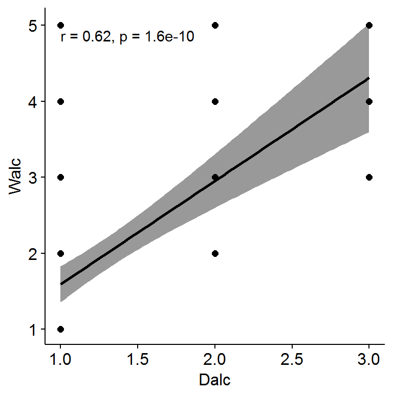

```r
library(ggpubr)

math_por <- read.table("data/math_por.csv",header=T, sep="\t")
pairs(math_por[c(31,32)], panel = panel.smooth)
pairs(math_por[c(38,39)], panel = panel.smooth)

ggscatter(math_por, x = "Medu", y = "Fedu",
          add = "reg.line", conf.int = TRUE,
          cor.coef = TRUE, cor.method = "spearman",
          xlab = "Medu", ylab = "Fedu")
ggscatter(math_por, x = "Dalc", y = "Walc",
          add = "reg.line", conf.int = TRUE,
          cor.coef = TRUE, cor.method = "spearman",
          xlab = "Dalc", ylab = "Walc")
```

The histogram and bar plots of my response variables (G3.math and G3.por) both in their continous forms as well as the binary variables I created from these continous variables in the data wrangling part is shown below. For the 85 students selected for the analyses in this project, most students failed(their grades were below 13, maximum being 20) in both subjects.

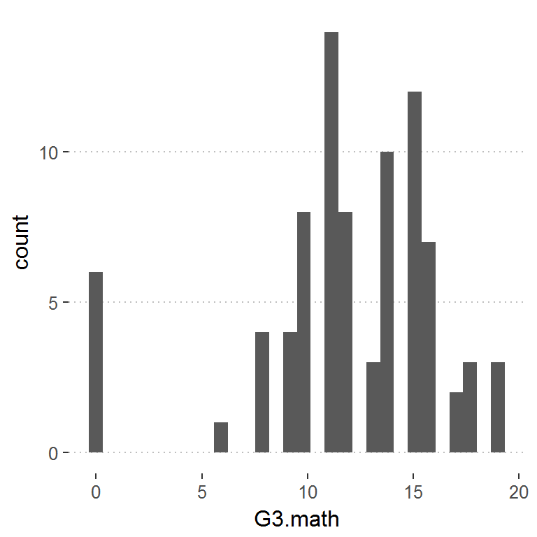

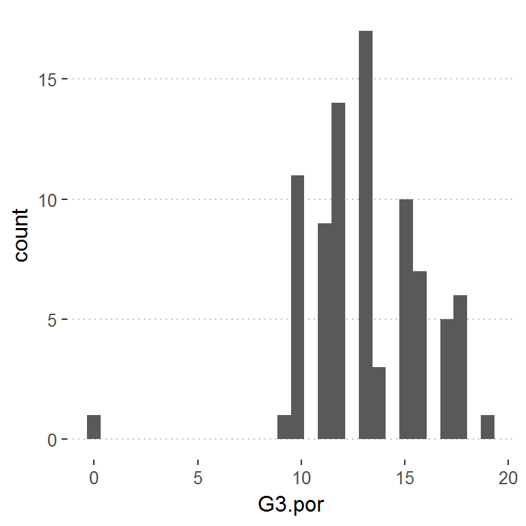

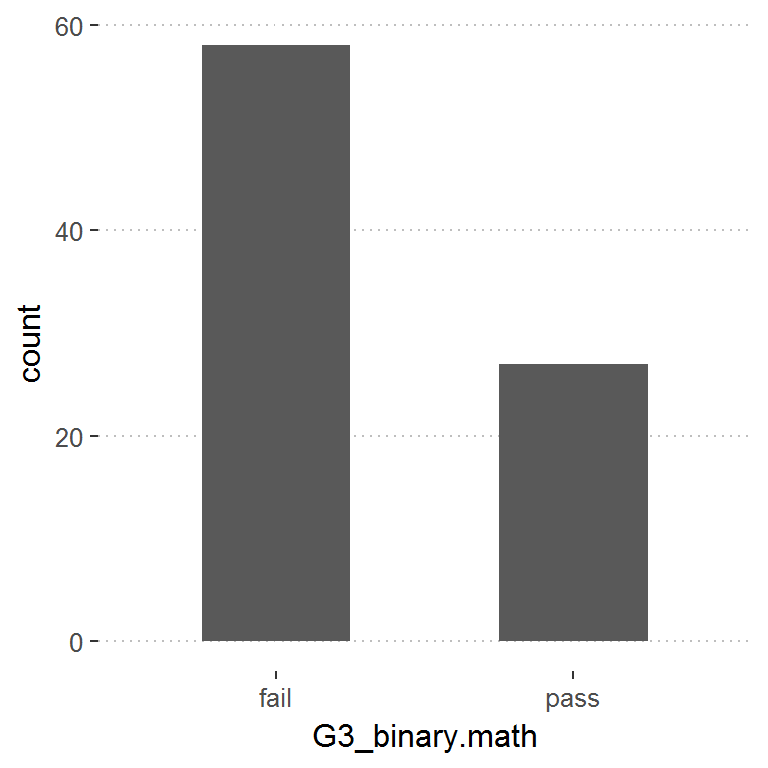

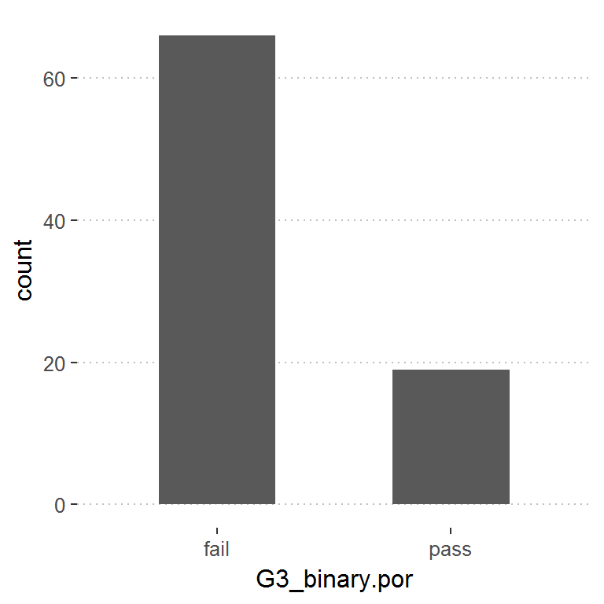

```r
library(ggplot2)

ggplot(math_por, aes(x=G3.math)) + geom_histogram()+theme_pubclean()
ggplot(math_por, aes(x=G3.por)) + geom_histogram()+theme_pubclean()

mathPor2_scaled <- read.table("data/mathPor2_scaled.csv",header=T, sep="\t")
ggplot(mathPor2_scaled, aes(x=G3_binary.math)) + geom_bar(width=0.5)+theme_pubclean()
ggplot(mathPor2_scaled, aes(x=G3_binary.por)) + geom_bar(width=0.5)+theme_pubclean()
```

# 5. Method description

## 5.1-Linear regression

First I will do a linear regression of the final math and portugese grades (separately) with all the variables except those that might be specific to the two subjects(such as weekly study time,extra educational school support,family educational support,extra paid classes) which is done in the data wrangling part and also except the previous two grades.Then I will regress my response variables against those predictors that had low VIF values as described above and also in the data wrangling part.

Since the previous two grades would highly affect the final grade, I wanted to see which other variables might affect the final grade and so did not include the previous grades in my analyses. I am fitting models separately for the two subjects to see if the signinficant explanatory variables differ and i could have done this before merging the two datasets but i wanted to do it on only those students whose info matches on almost all variables between both subjects.

In Linear Regression, we are looking for a linear combination of predictor variables that explain(covary) with our response variable. In this case, the final grade will be our response variable and we will regress it against the predictors we chose.

**The summary of the fitted model that used all the predictor variables(except the subject specific ones and the previous two grades) for the final mathematics grade is shown below**

```r
library(dplyr)
library(MASS)
library(car)
library(VIF)
math_por <- read.table("data/math_por.csv",header=T, sep="\t")

#math
math2 <- math_por %>% dplyr::select(-one_of('G1.math','G2.math','paid.por','G1.por','G2.por','G3.por','studytime.por','schoolsup.por','famsup.por'))


mathGrade_lm<-lm(G3.math~., data=math2)

summary(mathGrade_lm)
```

```
Call:
lm(formula = G3.math ~ ., data = math2)

Residuals:
    Min      1Q  Median      3Q     Max
-5.8371 -2.0327  0.3623  1.7010  4.6208

Coefficients:
                  Estimate Std. Error t value Pr(>|t|)
(Intercept)       36.06708   11.09973   3.249  0.00219 **
schoolMS           1.82635    1.72620   1.058  0.29569
sexM               0.44090    1.22948   0.359  0.72157
age               -1.32258    0.56291  -2.350  0.02324 *
addressU          -0.02025    1.58626  -0.013  0.98987
famsizeLE3         0.92672    1.17307   0.790  0.43367
PstatusT          -4.21802    1.85054  -2.279  0.02744 *
Medu               0.08133    0.79321   0.103  0.91879
Fedu               0.33299    0.72454   0.460  0.64802
Mjobhealth         5.42195    2.72049   1.993  0.05235 .
Mjobother         -3.38267    1.65366  -2.046  0.04667 *
Mjobservices       0.89489    1.98820   0.450  0.65480
Mjobteacher       -2.26993    2.37553  -0.956  0.34441
Fjobhealth        -6.19525    2.90481  -2.133  0.03843 *
Fjobother         -0.40111    2.36549  -0.170  0.86611
Fjobservices      -5.68907    2.53052  -2.248  0.02951 *
Fjobteacher        0.58453    2.76684   0.211  0.83364
reasonhome        -3.52625    1.30500  -2.702  0.00968 **
reasonother       -1.73187    2.02787  -0.854  0.39761
reasonreputation  -1.38623    1.34208  -1.033  0.30717
nurseryyes         1.17132    1.23329   0.950  0.34731
internetyes       -2.15213    1.60781  -1.339  0.18744
guardianmother    -1.79968    1.16410  -1.546  0.12911
guardianother     -1.61822    2.88783  -0.560  0.57802
traveltime         2.35715    1.15460   2.042  0.04709 *
failures          -3.43407    1.54519  -2.222  0.03132 *
activitiesyes     -0.11854    1.02273  -0.116  0.90824
higheryes          0.53045    5.01146   0.106  0.91617
romanticyes       -1.51455    1.02529  -1.477  0.14659
famrel             0.27421    0.81528   0.336  0.73818
freetime           0.69728    0.55307   1.261  0.21390
goout             -0.45449    0.52097  -0.872  0.38763
Dalc              -0.55481    1.19535  -0.464  0.64479
Walc               0.41854    0.59869   0.699  0.48809
health             0.27270    0.38647   0.706  0.48406
absences           0.04416    0.19261   0.229  0.81971
studytime.math     0.71776    0.63340   1.133  0.26313
schoolsup.mathyes -3.05353    1.58406  -1.928  0.06022 .
famsup.mathyes    -0.95550    1.23591  -0.773  0.44350
paid.mathyes       0.29542    1.22952   0.240  0.81121
---
Signif. codes:  0 '***' 0.001 '**' 0.01 '*' 0.05 '.' 0.1 ' ' 1

Residual standard error: 3.543 on 45 degrees of freedom
Multiple R-squared:   0.65, Adjusted R-squared:  0.3467
F-statistic: 2.143 on 39 and 45 DF,  p-value: 0.007164
```

```r
# this we got from the data wrangling part that used VIF iteratively with lm to backward select predictor variables (taken from this website https://beckmw.wordpress.com/2013/02/05/collinearity-and-stepwise-vif-selection/)
```

**And the summary of the other model that doesn’t include the variables ‘medu, traveltime,walc’ based on the VIF analysis is shown below.**

```r
form.in = "G3.math ~ school+sex+age+address+famsize+Pstatus+Fedu+Mjob+Fjob+reason+nursery+internet+guardian+failures+activities+higher+romantic+famrel+freetime+goout+Dalc+health+absences+studytime.math+schoolsup.math+famsup.math+paid.math"

mathGrade_lm2<-lm(form.in,data=math2)

summary(mathGrade_lm2)
```

```
Call:
lm(formula = form.in, data = math2)

Residuals:
   Min     1Q Median     3Q    Max
-7.006 -1.604  0.079  2.111  5.181

Coefficients:
                  Estimate Std. Error t value Pr(>|t|)
(Intercept)       36.49547   11.22101   3.252   0.0021 **
schoolMS           1.72549    1.73021   0.997   0.3236
sexM              -0.03202    1.19196  -0.027   0.9787
age               -1.05632    0.55014  -1.920   0.0608 .
addressU          -1.31880    1.45804  -0.905   0.3702
famsizeLE3         1.92347    1.08786   1.768   0.0834 .
PstatusT          -4.12821    1.84487  -2.238   0.0299 *
Fedu               0.42570    0.60867   0.699   0.4877
Mjobhealth         5.37121    2.30199   2.333   0.0239 *
Mjobother         -3.01268    1.60961  -1.872   0.0674 .
Mjobservices       0.55942    1.94196   0.288   0.7745
Mjobteacher       -2.11164    2.19723  -0.961   0.3413
Fjobhealth        -5.57486    2.89790  -1.924   0.0603 .
Fjobother          0.02766    2.25004   0.012   0.9902
Fjobservices      -4.49817    2.39937  -1.875   0.0669 .
Fjobteacher        1.31543    2.53975   0.518   0.6069
reasonhome        -3.63433    1.29702  -2.802   0.0073 **
reasonother       -1.38038    2.01696  -0.684   0.4970
reasonreputation  -1.52479    1.31825  -1.157   0.2531
nurseryyes         1.35970    1.14620   1.186   0.2414
internetyes       -1.54470    1.60186  -0.964   0.3397
guardianmother    -2.14022    1.15515  -1.853   0.0701 .
guardianother     -2.32701    2.86689  -0.812   0.4210
failures          -2.15348    1.41104  -1.526   0.1335
activitiesyes     -0.40700    0.97328  -0.418   0.6777
higheryes         -0.03215    5.06920  -0.006   0.9950
romanticyes       -1.71414    1.01352  -1.691   0.0973 .
famrel             0.12638    0.78704   0.161   0.8731
freetime           0.53284    0.52211   1.021   0.3126
goout             -0.33351    0.48813  -0.683   0.4977
Dalc               0.10553    0.97584   0.108   0.9143
health             0.11883    0.37385   0.318   0.7520
absences           0.12633    0.18593   0.679   0.5001
studytime.math     0.63280    0.60789   1.041   0.3031
schoolsup.mathyes -3.85360    1.55084  -2.485   0.0165 *
famsup.mathyes    -0.37955    1.20778  -0.314   0.7547
paid.mathyes       0.05947    1.18770   0.050   0.9603
---
Signif. codes:  0 '***' 0.001 '**' 0.01 '*' 0.05 '.' 0.1 ' ' 1

Residual standard error: 3.599 on 48 degrees of freedom
Multiple R-squared:  0.6148,    Adjusted R-squared:  0.3258
F-statistic: 2.128 on 36 and 48 DF,  p-value: 0.007407
```

**The same is done for the portugese final grade and the summary of the two models are shown below.**

```r
#portugese
por2 <- math_por %>% dplyr::select(-one_of('G1.por','G2.por','paid.math','G1.math','G2.math','G3.math','studytime.math','schoolsup.math','famsup.math'))
porGrade_lm<-lm(G3.por~., data=por2)
summary(porGrade_lm)
```

```
Call:
lm(formula = G3.por ~ ., data = por2)

Residuals:
    Min      1Q  Median      3Q     Max
-5.5953 -1.1487 -0.0102  1.2250  5.0192

Coefficients:
                 Estimate Std. Error t value Pr(>|t|)
(Intercept)      14.87461    8.46493   1.757   0.0857 .
schoolMS         -0.01804    1.32012  -0.014   0.9892
sexM             -0.80068    0.93883  -0.853   0.3983
age               0.02233    0.42713   0.052   0.9585
addressU         -0.42769    1.20910  -0.354   0.7252
famsizeLE3        0.77216    0.88990   0.868   0.3902
PstatusT         -1.16401    1.40707  -0.827   0.4125
Medu              0.47546    0.60315   0.788   0.4347
Fedu             -0.28916    0.54487  -0.531   0.5982
Mjobhealth        1.74412    2.07837   0.839   0.4058
Mjobother        -1.52121    1.26878  -1.199   0.2368
Mjobservices      0.22747    1.52692   0.149   0.8822
Mjobteacher      -0.82520    1.86477  -0.443   0.6602
Fjobhealth       -1.41533    2.11763  -0.668   0.5073
Fjobother        -0.47941    1.75930  -0.273   0.7865
Fjobservices     -2.08338    1.82272  -1.143   0.2591
Fjobteacher       0.71667    2.06640   0.347   0.7303
reasonhome       -0.64785    0.97508  -0.664   0.5098
reasonother      -1.21670    1.57287  -0.774   0.4432
reasonreputation -0.72752    0.99531  -0.731   0.4686
nurseryyes       -0.16162    0.94401  -0.171   0.8648
internetyes       0.82171    1.12400   0.731   0.4685
guardianmother   -1.06862    0.87540  -1.221   0.2286
guardianother    -1.90299    2.00299  -0.950   0.3471
traveltime       -0.04526    0.88042  -0.051   0.9592
failures         -1.46143    1.18704  -1.231   0.2247
activitiesyes     0.01579    0.78065   0.020   0.9840
higheryes         3.30278    3.84946   0.858   0.3954
romanticyes      -0.04700    0.77029  -0.061   0.9516
famrel           -0.30892    0.59035  -0.523   0.6033
freetime         -0.14372    0.42270  -0.340   0.7354
goout            -0.07901    0.39706  -0.199   0.8432
Dalc              1.01604    0.92447   1.099   0.2776
Walc             -0.35976    0.45416  -0.792   0.4324
health           -0.44293    0.29282  -1.513   0.1374
absences          0.02833    0.14705   0.193   0.8481
studytime.por     0.49641    0.49138   1.010   0.3178
schoolsup.poryes -2.95551    1.21980  -2.423   0.0195 *
famsup.poryes     0.54237    0.84178   0.644   0.5226
paid.poryes      -1.48251    1.78061  -0.833   0.4095
---
Signif. codes:  0 '***' 0.001 '**' 0.01 '*' 0.05 '.' 0.1 ' ' 1

Residual standard error: 2.714 on 45 degrees of freedom
Multiple R-squared:  0.528, Adjusted R-squared:  0.1189
F-statistic: 1.291 on 39 and 45 DF,  p-value: 0.2037
```

```r
form.in.por = "G3.por ~ school+sex+age+address+famsize+Pstatus+Fedu+Mjob+Fjob+reason+nursery+internet+guardian+failures+activities+higher+romantic+famrel+freetime+goout+Dalc+health+absences+studytime.por+schoolsup.por+famsup.por+paid.por"

porGrade_lm2<-lm(form.in.por,data=por2)

summary(porGrade_lm2)
```

```
Call:
lm(formula = form.in.por, data = por2)

Residuals:
    Min      1Q  Median      3Q     Max
-5.8624 -1.2197  0.0618  1.4096  4.4359

Coefficients:
                 Estimate Std. Error t value Pr(>|t|)
(Intercept)      15.24570    8.23809   1.851   0.0704 .
schoolMS         -0.24289    1.28150  -0.190   0.8505
sexM             -0.65425    0.88821  -0.737   0.4650
age               0.02383    0.40287   0.059   0.9531
addressU         -0.40890    1.07557  -0.380   0.7055
famsizeLE3        0.72694    0.80256   0.906   0.3696
PstatusT         -1.09733    1.34371  -0.817   0.4182
Fedu             -0.05905    0.45442  -0.130   0.8971
Mjobhealth        2.33007    1.72159   1.353   0.1823
Mjobother        -1.26416    1.19007  -1.062   0.2934
Mjobservices      0.68783    1.42341   0.483   0.6311
Mjobteacher      -0.19949    1.64165  -0.122   0.9038
Fjobhealth       -1.75474    2.05938  -0.852   0.3984
Fjobother        -0.47127    1.64859  -0.286   0.7762
Fjobservices     -2.18791    1.71426  -1.276   0.2080
Fjobteacher       0.70982    1.87360   0.379   0.7065
reasonhome       -0.78253    0.92458  -0.846   0.4016
reasonother      -1.56730    1.49650  -1.047   0.3002
reasonreputation -0.71830    0.95677  -0.751   0.4565
nurseryyes        0.25822    0.83764   0.308   0.7592
internetyes       0.72341    1.09058   0.663   0.5103
guardianmother   -0.90490    0.84491  -1.071   0.2895
guardianother    -1.52241    1.94138  -0.784   0.4368
failures         -1.71042    1.04924  -1.630   0.1096
activitiesyes    -0.18865    0.72290  -0.261   0.7952
higheryes         2.96566    3.76384   0.788   0.4346
romanticyes       0.08338    0.73996   0.113   0.9108
famrel           -0.26562    0.56363  -0.471   0.6396
freetime         -0.25599    0.39070  -0.655   0.5155
goout            -0.17779    0.36186  -0.491   0.6254
Dalc              0.55896    0.72979   0.766   0.4475
health           -0.49037    0.26961  -1.819   0.0752 .
absences          0.04455    0.13946   0.319   0.7508
studytime.por     0.70726    0.45028   1.571   0.1228
schoolsup.poryes -2.91585    1.16065  -2.512   0.0154 *
famsup.poryes     0.46600    0.80825   0.577   0.5669
paid.poryes      -0.87283    1.67022  -0.523   0.6037
---
Signif. codes:  0 '***' 0.001 '**' 0.01 '*' 0.05 '.' 0.1 ' ' 1

Residual standard error: 2.669 on 48 degrees of freedom
Multiple R-squared:  0.5131,    Adjusted R-squared:  0.1479
F-statistic: 1.405 on 36 and 48 DF,  p-value: 0.1346
```

## 5.2-LDA

As an additional method, I used LDA to classify students and predict students’ Portugese and mathematics grades based on the numeric variables only which were scaled in the data wrangling part (and i have also removed collinear varibales before fitting LDA).In LDA we are looking for a linear combination of features that will separate two or more classes as such it can also be used for dimensional reduction. Since the response variables must be categorical, I categorized the grades in to ‘pass’(>=13) and ‘fail’ before fitting the LDA models.

Again I am fitting models separately for the two subjects and taking 80% of the data for training and the rest 20% for testing.

**The plots of the fitting and the cross tabulation tables for the mathematics final grade are depicted below.**

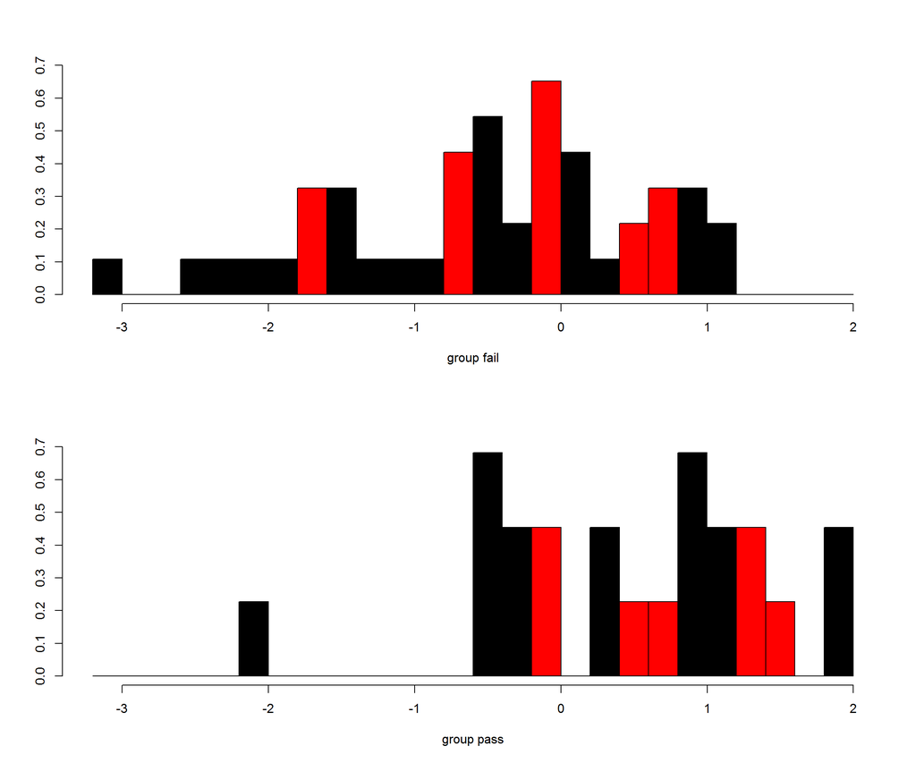

```r
set.seed(54)
mathPor2_scaled <- read.table("data/mathPor2_scaled.csv",header=T, sep="\t")
#math
math3 <- mathPor2_scaled %>% dplyr::select(-one_of('G3_binary.por','G1.math','G2.math','G1.por','G2.por','studytime.por','Fedu','Walc'))
# sample 80 percent of the data, i.e. you have the row indices here
ind <- sample(nrow(math3),  size = nrow(math3) * 0.8)

# based on those indices we choose our training set
train <- math3[ind,]
# the rest is the test data
test <- math3[-ind,]

# we know the correct classes from our test set
correct_classes <- test$G3_binary.math

# remove the grade classes, so that we replace them with the predicted values from the next steps
test <- dplyr::select(test, -G3_binary.math)

lda.fit <- lda(G3_binary.math ~ . , data = train)

classes <- as.numeric(train$G3_binary.math)

plot(lda.fit, dimen = 2,col = classes,pch=classes)
```

```r
lda.pred <- predict(lda.fit, newdata = test)

# cross tabulate the results
table(correct = correct_classes, predicted = lda.pred$class)
```

```
       predicted
correct fail pass
   fail    9    3
   pass    3    2
```

**And for the Portugese:**

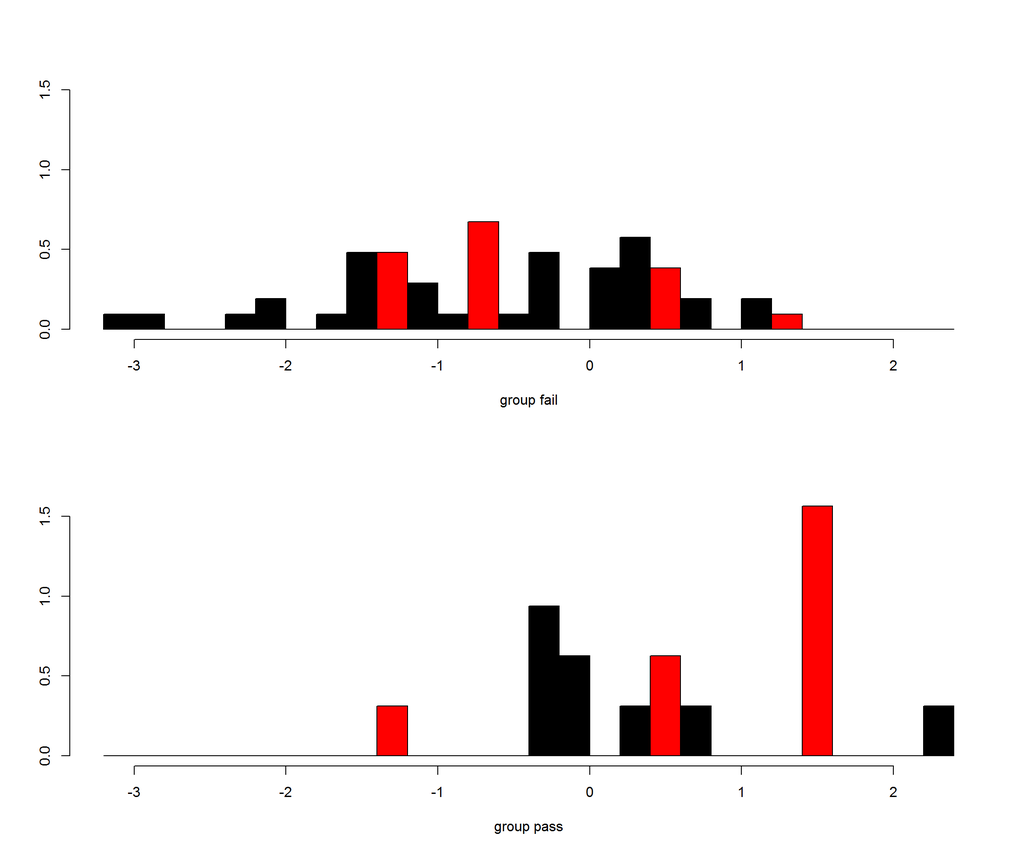

```r
set.seed(42)
# por
por3 <- mathPor2_scaled %>% dplyr::select(-one_of('G3_binary.math','G1.math','G2.math','G1.por','G2.por','studytime.por','Fedu','Walc'))

# sample 80 percent of the data, i.e. you have the row indices here
ind.por <- sample(nrow(por3),  size = nrow(por3) * 0.8)

# based on those indices we choose our training set
train.por <- por3[ind.por,]
# the rest is the test data
test.por <- por3[-ind.por,]

# we know the correct classes from our test set
correct_classes.por <- test.por$G3_binary.por

# remove the grade classes, so that we replace them with the predicted values from the next steps
test.por <- dplyr::select(test.por, -G3_binary.por)

lda.fit.por <- lda(G3_binary.por ~ . , data = train.por)

classes.por <- as.numeric(train.por$G3_binary.por)
plot(lda.fit.por, dimen = 2,col = classes.por,pch=classes.por)
```

```r
lda.pred.por <- predict(lda.fit.por, newdata = test.por)

# cross tabulate the results
table(correct = correct_classes.por, predicted = lda.pred.por$class)
```

```
       predicted
correct fail pass
   fail   12    2
   pass    3    0
```

# 6.Results and Interpretations

In the first Linear regression model where I didn’t select predictors with low VIFs, the value ‘home’ of the variable ‘reason to choose school’, appears to have a high statistically significant relation to the final mathematics grade and the relation is negative, i.e. the final grades are lower for those students who chose a school only because it was closer to home. In addition, the variables age,whether or not the parents are living together, the mother’s job categorized as other, Father’s job categorized as health and civil services, the home to school travel time and previous school failures are also related to the final grades. However, the sign of the relationships between some of these variables and the final grade are not very initutive. For instance, I would expect the final grades of students whose parents are living together to increase and not decrease.

For the final Portugese grade on the contrary, only the ‘extra educational school support’ variable(with value yes) appears to be statistically significantly related to the grade and the relation is negative which again doesn’t make sense.

The adjusted residual square errors of the all-variable models of both the final mathematics and Portugese grades are very low indicating the fit is not optimal (using these models we could explain only ~35% and 12% of the variations in our response variables respectively). We can also check the distribution of the residuals from diagnostics plots of the lm objects to assess if the following key assumptions are met:

```r
mean(mathGrade_lm$residuals)
```

```
[1] -2.286774e-17
```

```r
mean(porGrade_lm$residuals)
```

```
[1] -2.420449e-17
```

```r
library(car)

ncvTest(mathGrade_lm)
```

```
Non-constant Variance Score Test
Variance formula: ~ fitted.values
Chisquare = 1.393119    Df = 1     p = 0.2378791
```

```r
ncvTest(porGrade_lm)
```

```
Non-constant Variance Score Test
Variance formula: ~ fitted.values
Chisquare = 1.40886    Df = 1     p = 0.2352458
```

```r
durbinWatsonTest(mathGrade_lm)
```

```
 lag Autocorrelation D-W Statistic p-value
   1     -0.04464933      2.046944   0.652
 Alternative hypothesis: rho != 0
```

```r
durbinWatsonTest(porGrade_lm)
```

```
 lag Autocorrelation D-W Statistic p-value
   1     -0.02005338      1.945137   0.334
 Alternative hypothesis: rho != 0
```

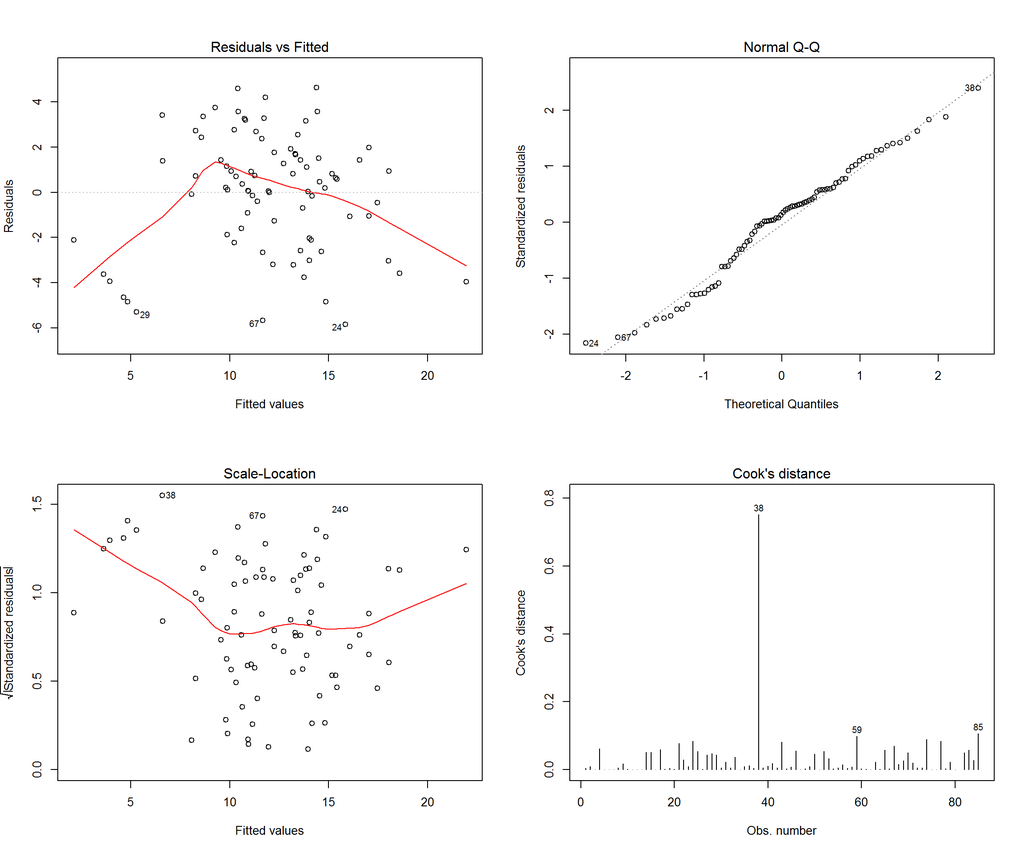

```r
OP <- par(mfrow = c(2,2))
plot(mathGrade_lm, which = c(1:4))
```

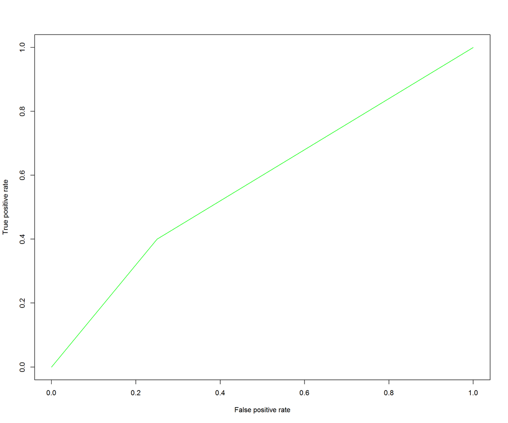

```r
par(OP)

library(ROCR)

prediction(as.numeric(lda.pred$class), as.numeric(correct_classes)) %>%
  performance(measure = "tpr", x.measure = "fpr") %>%
  plot(col="green")
```

For Portugese:

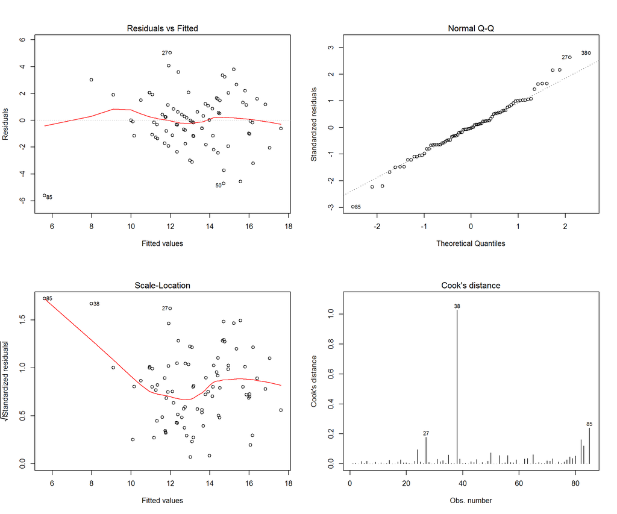

```r
OP <- par(mfrow = c(2,2))
plot(porGrade_lm, which = c(1:4))
```

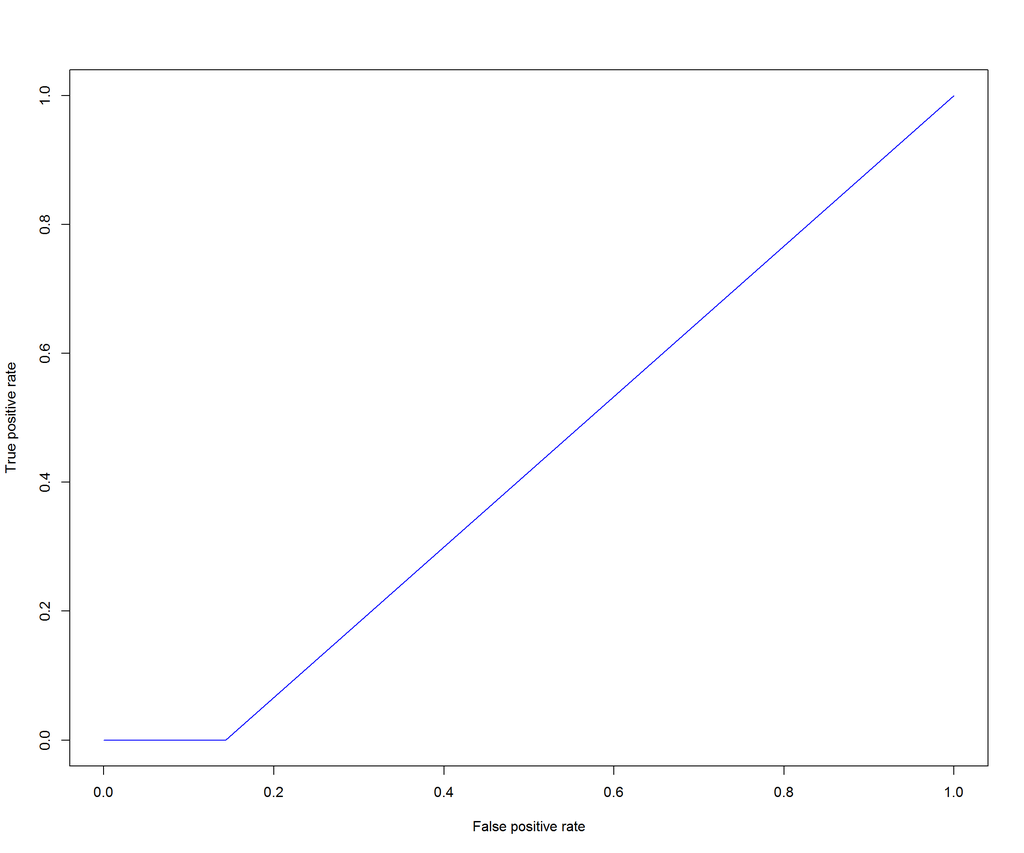

```r
par(OP)


prediction(as.numeric(lda.pred.por$class), as.numeric(correct_classes.por)) %>%
  performance(measure = "tpr", x.measure = "fpr") %>%
  plot(col="blue")
```

```r
prediction(as.numeric(lda.pred.por$class), as.numeric(correct_classes.por)) %>%
  performance(measure = "auc") %>%
  .@y.values
```

```
[[1]]
[1] 0.4285714
```

```r
prediction(as.numeric(lda.pred$class), as.numeric(correct_classes)) %>%
  performance(measure = "auc") %>%
  .@y.values
```

```
[[1]]
[1] 0.575
```

On the other hand, for the models that used variables with low VIF values, while for the final mathemaics grade the ‘reasonhome, Mjobhealth, PstatusT and schoolsup.mathyes’ had siginificant relations, for the Portugese final grade, as in the previous model only ‘schoolsup.poryes’ had a significant relationship. There wasn’t also a significant difference from the previous models interms of the adjusted R-squared and the p-values of the F statisitics as assessed using the anova() method (p-value 0.22).

To compare either of these methods to a model that uses only the previous grades I also fitted a model that regresses the final grade against the two previous grades. As expected the fit of the model is improved as can be judged from the adjusted R-squared which increased to 0.78 when we used the previous grades.

```r
math_lm5 <- lm(G3.math~G1.math+G2.math, data=math_por)
summary(math_lm5)
```

```
Call:
lm(formula = G3.math ~ G1.math + G2.math, data = math_por)

Residuals:
    Min      1Q  Median      3Q     Max
-9.1548 -0.3809  0.0478  0.9400  4.1193

Coefficients:
            Estimate Std. Error t value Pr(>|t|)
(Intercept)  -2.8338     0.8841  -3.205  0.00192 **
G1.math       0.1545     0.1681   0.919  0.36062
G2.math       1.0598     0.1705   6.216 2.02e-08 ***
---
Signif. codes:  0 '***' 0.001 '**' 0.01 '*' 0.05 '.' 0.1 ' ' 1

Residual standard error: 2.047 on 82 degrees of freedom
Multiple R-squared:  0.7871,    Adjusted R-squared:  0.7819
F-statistic: 151.5 on 2 and 82 DF,  p-value: < 2.2e-16
```

```r
anova(mathGrade_lm2,mathGrade_lm)
```

```
Analysis of Variance Table

Model 1: G3.math ~ school + sex + age + address + famsize + Pstatus +
    Fedu + Mjob + Fjob + reason + nursery + internet + guardian +
    failures + activities + higher + romantic + famrel + freetime +
    goout + Dalc + health + absences + studytime.math + schoolsup.math +
    famsup.math + paid.math
Model 2: G3.math ~ school + sex + age + address + famsize + Pstatus +
    Medu + Fedu + Mjob + Fjob + reason + nursery + internet +
    guardian + traveltime + failures + activities + higher +
    romantic + famrel + freetime + goout + Dalc + Walc + health +
    absences + studytime.math + schoolsup.math + famsup.math +
    paid.math
  Res.Df    RSS Df Sum of Sq      F Pr(>F)
1     48 621.79
2     45 564.91  3     56.88 1.5103 0.2247
```

# 7.Conclusions and Discussions